# Project Python Foundations: FoodHub Data Analysis

**Marks: 60**

### Context

The number of restaurants in New York is increasing day by day. Lots of students and busy professionals rely on those restaurants due to their hectic lifestyles. Online food delivery service is a great option for them. It provides them with good food from their favorite restaurants. A food aggregator company FoodHub offers access to multiple restaurants through a single smartphone app.

The app allows the restaurants to receive a direct online order from a customer. The app assigns a delivery person from the company to pick up the order after it is confirmed by the restaurant. The delivery person then uses the map to reach the restaurant and waits for the food package. Once the food package is handed over to the delivery person, he/she confirms the pick-up in the app and travels to the customer's location to deliver the food. The delivery person confirms the drop-off in the app after delivering the food package to the customer. The customer can rate the order in the app. The food aggregator earns money by collecting a fixed margin of the delivery order from the restaurants.

### Objective

The food aggregator company has stored the data of the different orders made by the registered customers in their online portal. They want to analyze the data to get a fair idea about the demand of different restaurants which will help them in enhancing their customer experience. Suppose you are hired as a Data Scientist in this company and the Data Science team has shared some of the key questions that need to be answered. Perform the data analysis to find answers to these questions that will help the company to improve the business.

### Data Description

The data contains the different data related to a food order. The detailed data dictionary is given below.

### Data Dictionary

- order_id: Unique ID of the order
- customer_id: ID of the customer who ordered the food
- restaurant_name: Name of the restaurant
- cuisine_type: Cuisine ordered by the customer
- cost: Cost of the order
- day_of_the_week: Indicates whether the order is placed on a weekday or weekend (The weekday is from Monday to Friday and the weekend is Saturday and Sunday)
- rating: Rating given by the customer out of 5
- food_preparation_time: Time (in minutes) taken by the restaurant to prepare the food. This is calculated by taking the difference between the timestamps of the restaurant's order confirmation and the delivery person's pick-up confirmation.
- delivery_time: Time (in minutes) taken by the delivery person to deliver the food package. This is calculated by taking the difference between the timestamps of the delivery person's pick-up confirmation and drop-off information

### Let us start by importing the required libraries

```python
# import libraries for data manipulation
import numpy as np
import pandas as pd

# import libraries for data visualization
import matplotlib.pyplot as plt
import seaborn as sns
```

### Understanding the structure of the data

```python
# read the data
df = pd.read_csv('foodhub_order.csv')
# returns the first 5 rows
df.head()
```

|  | order_id | customer_id | restaurant_name | cuisine_type | cost_of_the_order | day_of_the_week | rating | food_preparation_time | delivery_time |
| --- | --- | --- | --- | --- | --- | --- | --- | --- | --- |
| 0 | 1477147 | 337525 | Hangawi | Korean | 30.75 | Weekend | Not given | 25 | 20 |
| 1 | 1477685 | 358141 | Blue Ribbon Sushi Izakaya | Japanese | 12.08 | Weekend | Not given | 25 | 23 |
| 2 | 1477070 | 66393 | Cafe Habana | Mexican | 12.23 | Weekday | 5 | 23 | 28 |
| 3 | 1477334 | 106968 | Blue Ribbon Fried Chicken | American | 29.20 | Weekend | 3 | 25 | 15 |
| 4 | 1478249 | 76942 | Dirty Bird to Go | American | 11.59 | Weekday | 4 | 25 | 24 |

#### Observations:

- The DataFrame has 9 columns as mentioned in the Data Dictionary. Data in each row corresponds to an order placed by a customer.
- There is some data in the rating column that is not provided marked as "Not Given", as we will likley do some analysis on the rating against other data points, we will need to consider how to manage the missing rating information on some orders.

### **Question 1:** How many rows and columns are present in the data? [0.5 mark]

```python
# Print out the shape of the data to show rows and columns.
print("There are", df.shape[0], 'rows and', df.shape[1], "columns.")
```

```
There are 1898 rows and 9 columns.
```

#### Observations:

- There are 1898 rows of data with 9 columns.
- The data set is not that large so as we consider analysis of the dataset, time and complexity will likley not be major consideration.

### **Question 2:** What are the datatypes of the different columns in the dataset? (The info() function can be used) [0.5 mark]

```python
# Use info() to print a concise summary of the DataFrame
df.info()
```

```
<class 'pandas.core.frame.DataFrame'>
RangeIndex: 1898 entries, 0 to 1897
Data columns (total 9 columns):
 #   Column                 Non-Null Count  Dtype
---  ------                 --------------  -----
 0   order_id               1898 non-null   int64
 1   customer_id            1898 non-null   int64
 2   restaurant_name        1898 non-null   object
 3   cuisine_type           1898 non-null   object
 4   cost_of_the_order      1898 non-null   float64
 5   day_of_the_week        1898 non-null   object
 6   rating                 1898 non-null   object
 7   food_preparation_time  1898 non-null   int64
 8   delivery_time          1898 non-null   int64
dtypes: float64(1), int64(4), object(4)
memory usage: 133.6+ KB
```

#### Observations:

- Data for columns is a mixture of integer 64 bit (integer numbers), Object (string or mixed numeric/non-numeric) and float64 (floating point)
- The rating field being an object might be an issue as we start to analyze the data, we will come back to this later.
- All other data columns look to be the right format, we will need to evaluate missing data next.

### **Question 3:** Are there any missing values in the data? If yes, treat them using an appropriate method. [1 mark]

```python
#check to see if we have null data in any parts of the data frame.
df.isna().sum()
```

```
order_id                 0
customer_id              0
restaurant_name          0
cuisine_type             0
cost_of_the_order        0
day_of_the_week          0
rating                   0
food_preparation_time    0
delivery_time            0
dtype: int64
```

```python
#Check to see why rating column has object data type
df['rating'].unique()
```

```
array(['Not given', '5', '3', '4'], dtype=object)
```

```python
#replacing values with nan
df['rating'] = df['rating'].replace(['Not given'],np.nan)
```

```python
#converting the data type to a float so data analysis is possible in further analysis in plots alongside otther data
df['rating']=df['rating'].astype(float)
```

```python
#Creates a dataframe that will show all null values by column along with percentage column that contains this data.
pd.DataFrame({'Count':df.isnull().sum()[df.isnull().sum()>0],'Percentage':(df.isnull().sum()[df.isnull().sum()>0]/df.shape[0])*100})
```

|  | Count | Percentage |
| --- | --- | --- |
| rating | 736 | 38.777661 |

```python
#Checking for any duplicated data in the dataset.
df.duplicated().sum()
```

```
0
```

#### Observations:

- I found that there was data entered for rating as "Not Given". I converted to NaN and now we have null data in rating but this is okay. We could impute later to the mean of rating if we wanted but we will not do that in this case.
- I found no duplicated data across the data set.
- It was important to convert the rating column to float as we will want to plot and evaluate this with other data and numeric data will allow us to do this.

### **Question 4:** Check the statistical summary of the data. What is the minimum, average, and maximum time it takes for food to be prepared once an order is placed? [2 marks]

```python
# Calculate statistical data like percentile, mean and std of the numerical values of the food preparation column
df['food_preparation_time'].describe().T
```

```
count    1898.000000
mean       27.371970
std         4.632481
min        20.000000
25%        23.000000
50%        27.000000
75%        31.000000
max        35.000000
Name: food_preparation_time, dtype: float64
```

#### Observations:

- The average (mean) time to prep food is 27.37 minutes.
- The minimum (min) time to prep food is 20 minutes.
- The maximum time (max) to prep food is 35 minutes.

### **Question 5:** How many orders are not rated? [1 mark]

```python
# Checks how many orders are not rated
not_rated = df['rating'].isnull().sum()

print ('There are', not_rated, 'orders that are missing a rating')
```

```
There are 736 orders that are missing a rating
```

#### Observations:

- We found that 736 orders were missing a corresponding rating, we evaluated this by looking at the null values as we have already converted the "Not Given" values.

### Exploratory Data Analysis (EDA)

### **Question 6:** Explore all the variables and provide observations on their distributions. (Generally, histograms, boxplots, countplots, etc. are used for univariate exploration.) [9 marks]

#### Infomation about each variable in the data set to support univariate analysis

```python
# check unique order ID
num_orders = df['order_id'].nunique()

print('There are', num_orders, 'order id''s in the data set.' )
```

```
There are 1898 order ids in the data set.
```

```python
# check unique customer ID
num_customers = df['customer_id'].nunique()
print('There are', num_customers, 'customer id''s in the data set.' )
```

```
There are 1200 customer ids in the data set.
```

```python
# check unique restaurant names
num_restaurants = df['restaurant_name'].nunique()
print('There are', num_restaurants, 'restaurants in the data set.' )
```

```
There are 178 restaurants in the data set.
```

```python
# check unique cuisine
num_cuisines = df['cuisine_type'].nunique()
print('There are', num_cuisines, 'cuisines types in the data set.' )
```

```
There are 14 cuisines types in the data set.
```

```python
# check unique days of week
num_day_of_week = df['day_of_the_week'].nunique()
print('There are', num_day_of_week, 'days of the week in the data set.' )
```

```
There are 2 days of the week in the data set.
```

```python
# check cost of the order detail
df['cost_of_the_order'].describe()
```

```
count    1898.000000
mean       16.498851
std         7.483812
min         4.470000
25%        12.080000
50%        14.140000
75%        22.297500
max        35.410000
Name: cost_of_the_order, dtype: float64
```

```python
# check food prep time details
df['food_preparation_time'].describe()
```

```
count    1898.000000
mean       27.371970
std         4.632481
min        20.000000
25%        23.000000
50%        27.000000
75%        31.000000
max        35.000000
Name: food_preparation_time, dtype: float64
```

```python
# check delivery time details
df['delivery_time'].describe()
```

```
count    1898.000000
mean       24.161749
std         4.972637
min        15.000000
25%        20.000000
50%        25.000000
75%        28.000000
max        33.000000
Name: delivery_time, dtype: float64
```

```python
# check rating details
df['rating'].describe()
```

```
count    1162.000000
mean        4.344234
std         0.741478
min         3.000000
25%         4.000000
50%         5.000000
75%         5.000000
max         5.000000
Name: rating, dtype: float64
```

#### Plots that will provide for infomation that we can use to support univariate analysis (observations provided at end of question)

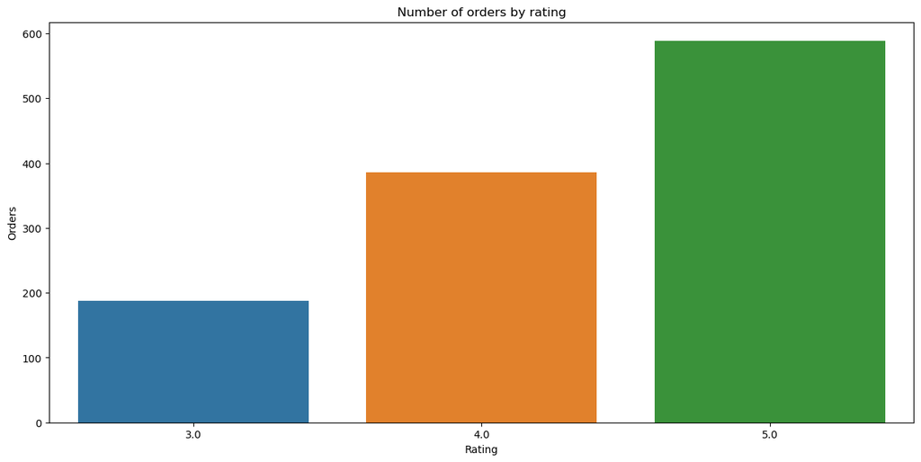

```python
#Set the plot size
plt.figure(figsize=(15, 7))

# Create seaborn countplot and provide count of orders by rating across all orders
cp_cuisine = sns.countplot(data=df, x='rating')
#specify axis labels
cp_cuisine.set(ylabel='Orders',
       xlabel='Rating',
       title='Number of orders by rating')

plt.show()
```

#### Observations

- All ratings are a 3, 4 or 5, there were no low ratings of 1 or 2 in the data set.
- More than 75% of the ratings are 4 or 5.

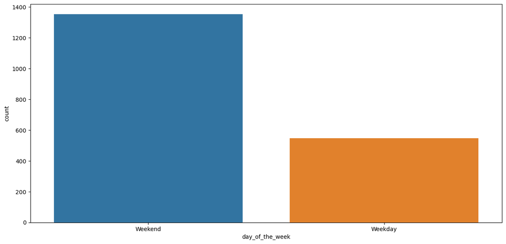

```python
#Set the plot size
plt.figure(figsize=(15, 7))

# Create seaborn countplot and provide count of orders by rating across all orders
week_cp = sns.countplot(data=df, x='day_of_the_week')
```

#### Oberservations

- More than 50% of the orders were on the weekend.

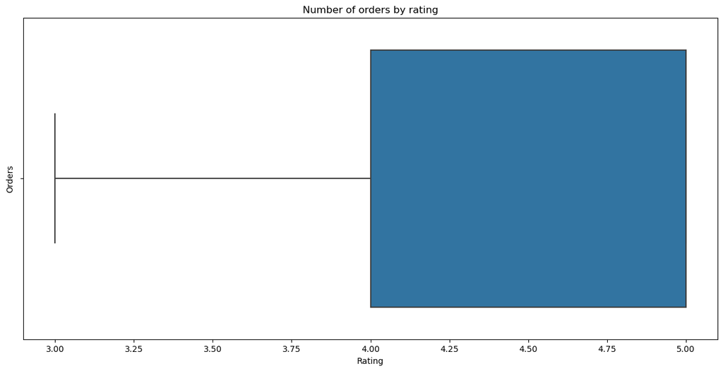

```python
#Set the plot size
plt.figure(figsize=(15, 7))

# Create seaborn countplot and provide count of orders by rating across all orders
cp_cuisine = sns.boxplot(data=df,x='rating')
#specify axis labels
cp_cuisine.set(ylabel='Orders',
       xlabel='Rating',
       title='Number of orders by rating')

plt.show()
```

#### Observations

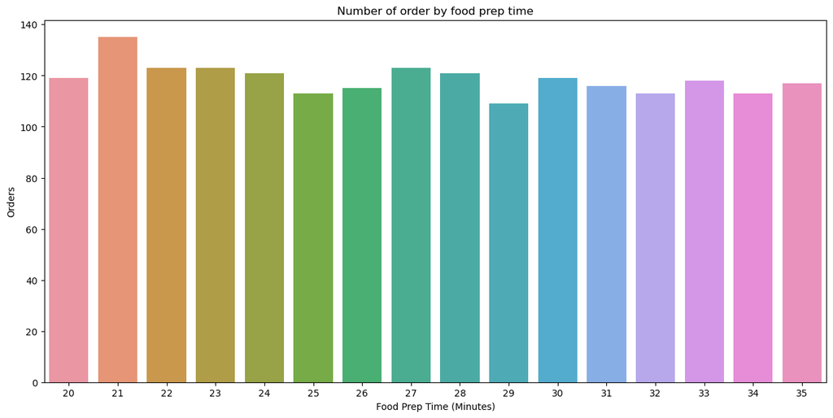

```python
#Set the plot size
plt.figure(figsize=(15, 7))

# Create seaborn histplot and provide count of orders by food preparation time across all orders
cp_cuisine = sns.countplot(data=df, x='food_preparation_time')
#specify axis labels
cp_cuisine.set(ylabel='Orders',
       xlabel='Food Prep Time (Minutes)',
       title='Number of order by food prep time')

plt.show()
```

#### Observations

- There is a pretty even distribution of the food prep time across all orders.

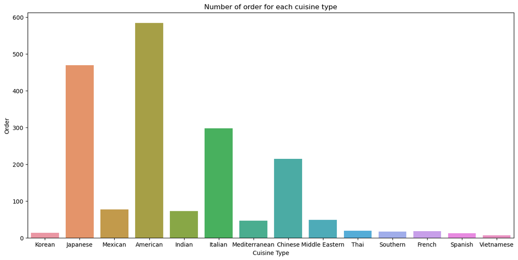

```python
#Set the plot size
plt.figure(figsize=(15, 7))

# Create seaborn countplot and provide count of orders by cuisine type across all orders
cp_cuisine = sns.countplot(data=df, x='cuisine_type')
#specify axis labels
cp_cuisine.set(ylabel='Order',
       xlabel='Cuisine Type',
       title='Number of order for each cuisine type')

plt.show()
```

#### Observations

- The cuisine type wth the most amount of orders was American.
- The cuisine type with least amount of orders was Vietnamese.

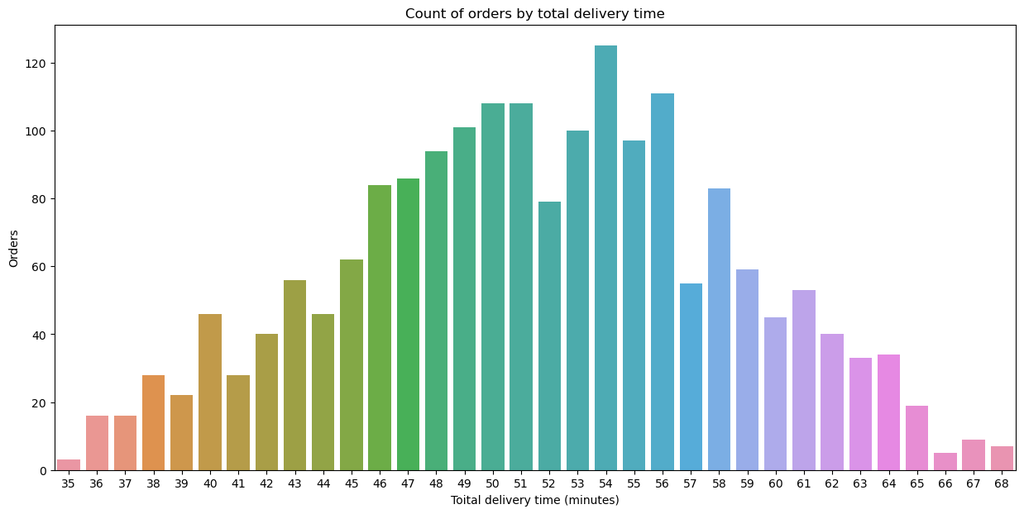

```python
#create a new column that adds delivery time and food prep time to produce total delivery time to see of we can find a relationship between total time and customer satisfaction or other things measures
df['total_delivery_time'] = df['delivery_time'] + df['food_preparation_time']


#Set plot size
plt.figure(figsize=(15, 7))

# Create seaborn countplot and provide count of the derived variable "total delivery time" time across all orders
cp_orders = sns.countplot(data=df, x='total_delivery_time')
#specify axis labels
cp_orders.set(ylabel='Orders',
       xlabel='Toital delivery time (minutes)',
       title='Count of orders by total delivery time')

plt.show()
```

#### observations

- The minimum total delivery time was around 35 minutes and the maximum around 68 minutes.

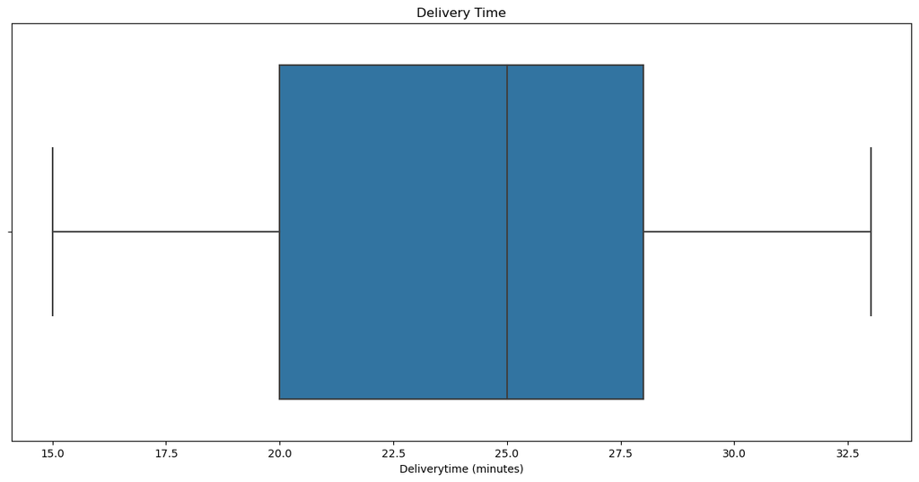

```python
# Set the plot size
plt.figure(figsize=(15, 7))
# Create seaborn boxplot to analyze the delivery time
box_delivery = sns.boxplot(data=df,x='delivery_time')

#set axis labels
box_delivery.set(
       xlabel='Deliverytime (minutes)',
       title='Delivery Time')

plt.show()
```

#### Observations

- The delivery time minimum time was 15 minutes, max was 33 around minutes. The median was 25 minutes.
- The box plot shows delivery time is somewhat left skewed.

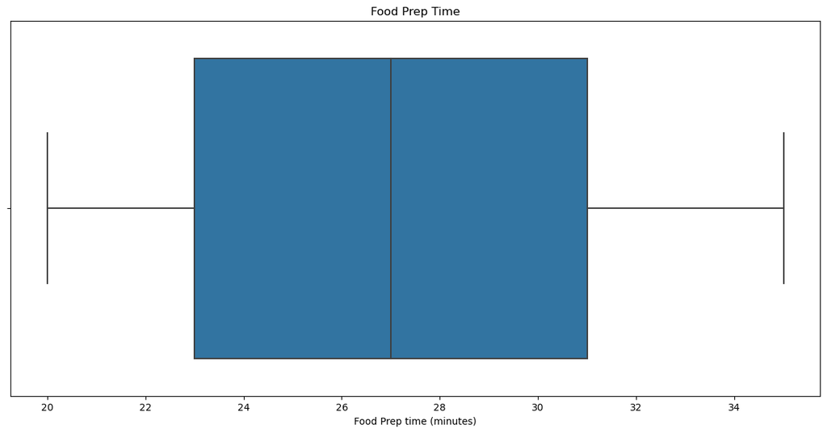

```python
# Set the plot size
plt.figure(figsize=(15, 7))
# Create seaborn boxplot to analyze the food preparation time
box_fp = sns.boxplot(data=df,x='food_preparation_time')

#set axis labels
box_fp.set(
       xlabel='Food Prep time (minutes)',
       title='Food Prep Time')

plt.show()
```

#### Observations

- The food prep time min value was 20 minutes, the max was 35 minutes and the mean wwas around 27 minutes.
- 50% of the data set had a food prep time of less than 27 minutes and 50% more than 27 minutes.

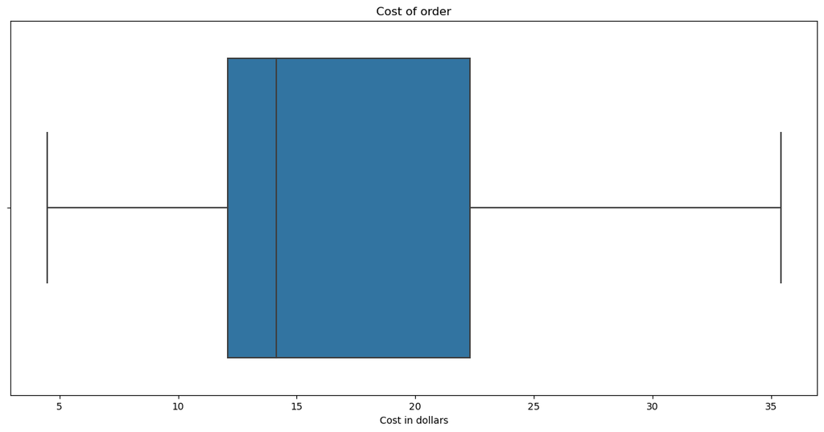

```python
# Set the plot size
plt.figure(figsize=(15, 7))
# Create seaborn boxplot to analyze the cost of order
box_cost = sns.boxplot(data=df,x='cost_of_the_order')

#set axis labels
box_cost.set(
       xlabel='Cost in dollars',
       title='Cost of order')

plt.show()
```

#### Observations

- Based on box plot for cost of order we can infer it is right skewed.

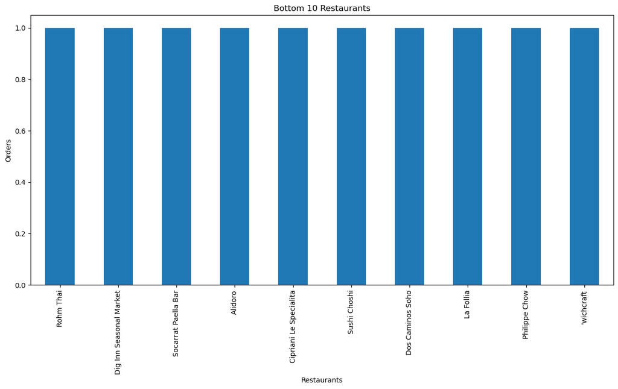

```python
#Show a Pandas bar chart of the bottom 10 restaurants in the amount of orders.
bottom_10 = (df['restaurant_name'].value_counts()).tail(10)

#create Pandas bar chart to visualize top 10 restaurants by order count
bottom_10.plot(kind='bar',title='Bottom 10 Restaurants',xlabel='Restaurants', ylabel='Orders',figsize=(15,7));
```

#### Observations

- The bottom 10 restaurants had a single order each

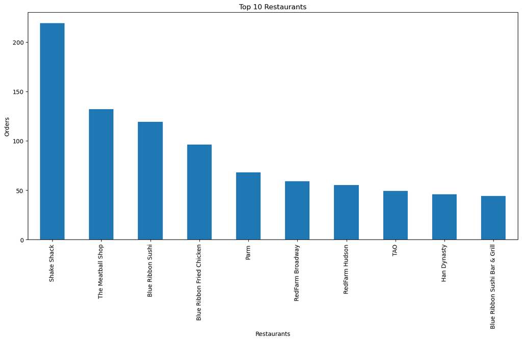

```python
#Show a Pandas bar chart of the top 10 restaurants in the amount of orders.
top_10 = (df['restaurant_name'].value_counts()).iloc[:10]

top_10
#create Pandas bar chart to visualize top 10 restaurants by order count
top_10.plot(kind='bar',title='Top 10 Restaurants',xlabel='Restaurants', ylabel='Orders',figsize=(15,7));
```

#### Observations

- Shake Shack is the restaurant with the most amount of orders at more than 200.
- All top 10 restaurants had a large amount of orders 44 plus.

### **Question 7**: Which are the top 5 restaurants in terms of the number of orders received? [1 mark]

```python
#Provides a count of the top 5 restaurants by the amount of orders.
df['restaurant_name'].value_counts().head(5)
```

```
Shake Shack                  219
The Meatball Shop            132
Blue Ribbon Sushi            119
Blue Ribbon Fried Chicken     96
Parm                          68
Name: restaurant_name, dtype: int64
```

#### Observations:

The top five restaurants are:

1. Shake Shack with 219 orders
2. The Meatball Shop with 132 orders
3. Blue Ribbon Sushi with 119 orders
4. Blue Ribbon Fried Chicken with 96 orders
5. Parm with 68 orders

### **Question 8**: Which is the most popular cuisine on weekends? [1 mark]

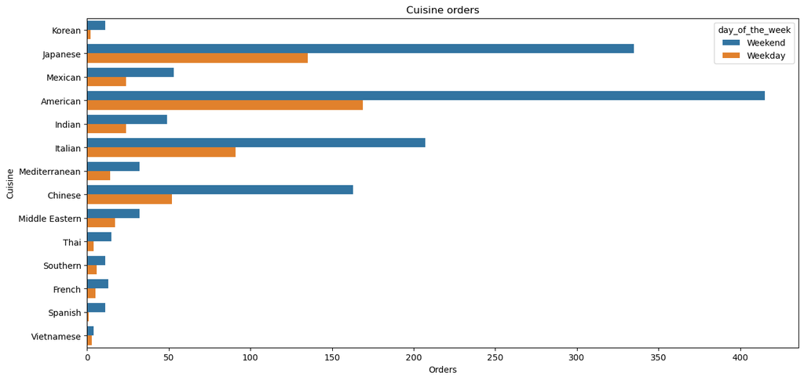

```python
#set the plotsize
plt.figure(figsize=(15, 7))
# Create seaborn pointplot to show relationship between food prep time and rating
count_cd = sns.countplot(data=df,y='cuisine_type', hue="day_of_the_week");


#set axis labels
count_cd.set(ylabel='Cuisine',
       xlabel='Orders',
       title='Cuisine orders');
```

#### Observations:

- The most popular cuisine on the weekends is American. It's also interesting this is the most popular cuisine on the weekdays.

### **Question 9**: What percentage of the orders cost more than 20 dollars? [2 marks]

```python
#Create a new column that returns true when the cost of the order is greater than 20 dollars, otherwise returns false
df['greater_than_twenty'] = np.where(df['cost_of_the_order']>20, True, False)

#provides a percentage of the values in the greater_than_twenty column
round(df['greater_than_twenty'].value_counts(normalize=True) * 100, 2)
```

```
False    70.76
True     29.24
Name: greater_than_twenty, dtype: float64
```

#### Observations:

- 29.24% of the orders in the data set were greater than 20 dollars.

### **Question 10**: What is the mean order delivery time? [1 mark]

```python
#calculate mean order delivery time
mean_delivery_time = round(df['delivery_time'].mean(),2)

# Prints the mean order delivery time rounded to 2 decimal places
print('The mean order delivery time is', mean_delivery_time, 'minutes.')
```

```
The mean order delivery time is 24.16 minutes.
```

#### Observations:

- The mean order delivery time in minutes rounded was 24.16 minutes.

### **Question 11:** The company has decided to give 20% discount vouchers to the top 3 most frequent customers. Find the IDs of these customers and the number of orders they placed. [1 mark]

```python
# This code prints out the top 3 customer id's in terms of # of orders
print('The top 3 customer IDs are:')
df['customer_id'].value_counts().head(3)
```

```
The top 3 customer IDs are:
```

```
52832    13
47440    10
83287     9
Name: customer_id, dtype: int64
```

#### Observations:

The top 3 customers are:

1. 52832 with 13 orders
2. 47440 with 10 orders
3. 83287 with 9 orders

### **Question 12**: Perform a multivariate analysis to explore relationships between the important variables in the dataset. (It is a good idea to explore relations between numerical variables as well as relations between numerical and categorical variables) [10 marks]

#### Cuisine type and day of week

### Food Prep Tme / Rating / day of the week

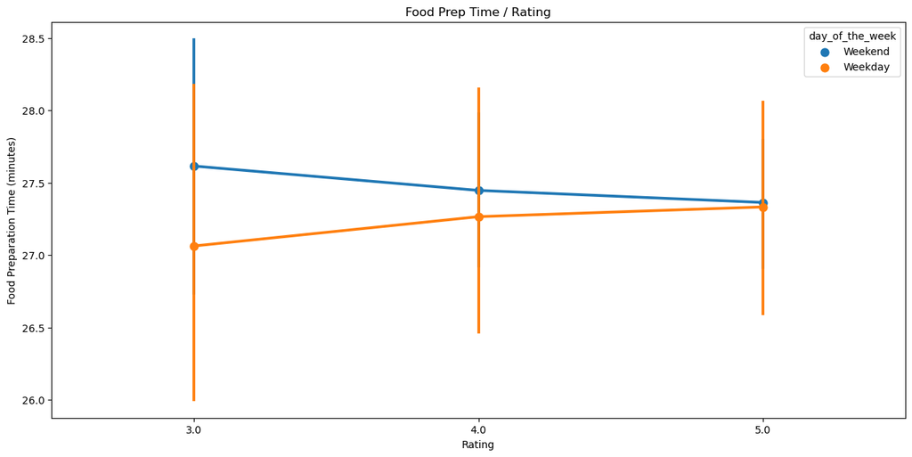

```python
#set the plotsize
plt.figure(figsize=(15, 7))
# Create seaborn pointplot show relationship between food prep time and rating
point_rd = sns.pointplot(x = 'rating', y ='food_preparation_time', hue= 'day_of_the_week', data = df)

#set axis labels
point_rd.set(ylabel='Food Preparation Time (minutes)',
       xlabel='Rating',
       title='Food Prep Time / Rating')

plt.show()
```

#### Observations

- Food prep time is pretty consistent acorss the orders, by rating and even on the differernt days.

### Delivery Time / Rating / Day of the week

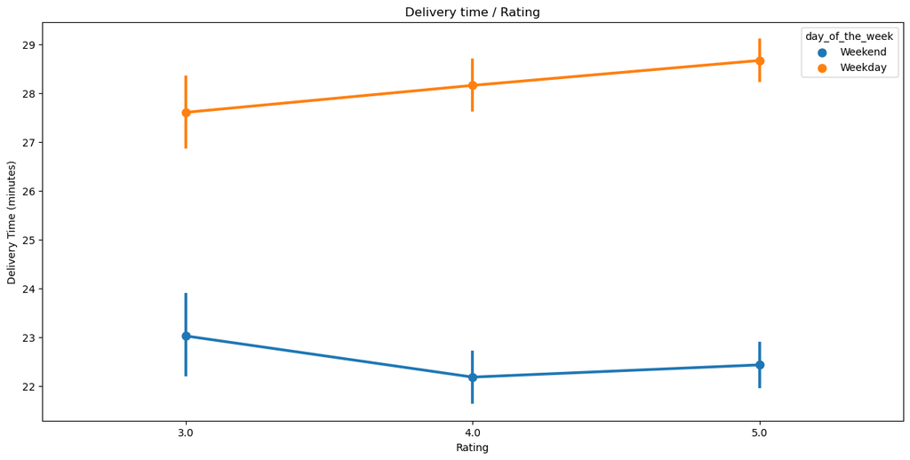

```python
#set the plotsize
plt.figure(figsize=(15, 7))
# Create seaborn pointplot to show delivery time and rating relationship
point_rd = sns.pointplot(x = 'rating', y ='delivery_time', hue= 'day_of_the_week', data = df)

#set axis labels
point_rd.set(ylabel='Delivery Time (minutes)',
       xlabel='Rating',
       title='Delivery time / Rating')

plt.show()
```

### Total Prep Tme / Rating / day of the week

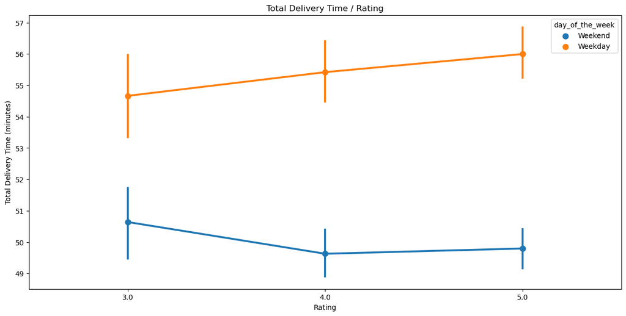

```python
#set the plotsize
plt.figure(figsize=(15, 7))
# Create seaborn pointplot t show relationship between total delivery time and rating
point_rtd = sns.pointplot(x = 'rating', y ='total_delivery_time', hue= 'day_of_the_week', data = df)

#set axis labels
point_rtd.set(ylabel='Total Delivery Time (minutes)',
       xlabel='Rating',
       title='Total Delivery Time / Rating')

plt.show()
```

### Food prep time by cuisine

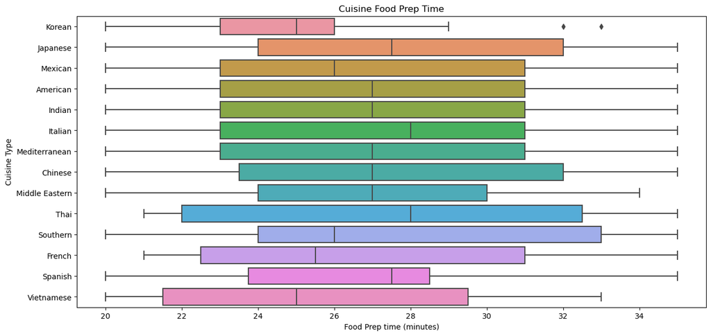

```python
# Set the plot size
plt.figure(figsize=(15, 7))
# Create seaborn boxplot to analyze the food preparation time for each cuisine type
box_cuisine_fp = sns.boxplot(data=df,x='food_preparation_time', y='cuisine_type')

#set axis labels
box_cuisine_fp.set(ylabel='Cuisine Type',
       xlabel='Food Prep time (minutes)',
       title='Cuisine Food Prep Time')

plt.show()
```

#### Observations

- Italian and Thai cuisines had the highest food prep time medians across all cuisines
- Vietnamese and Korean had the lowest median food prep time acorss all cuisines.
- Korean had a few outliers in the data set to the right for food prep time.

### Delivery time by cuisine

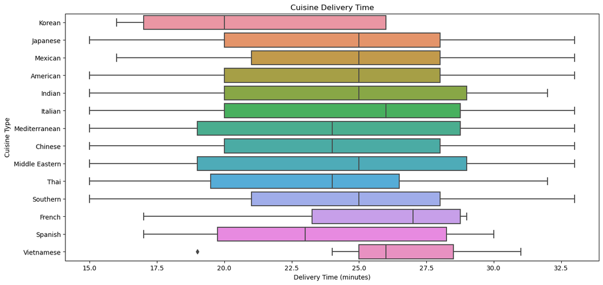

```python
# Set the plot size
plt.figure(figsize=(15, 7))

# Create seaborn boxplot to analyze the food delivery time for each cuisine type
box_cuisine_dt = sns.boxplot(data=df,x='delivery_time', y='cuisine_type')

#set axis labels
box_cuisine_dt.set(ylabel='Cuisine Type',
       xlabel='Delivery Time (minutes)',
       title='Cuisine Delivery Time')


plt.show()
```

### Food prep time on weekends and weekdays

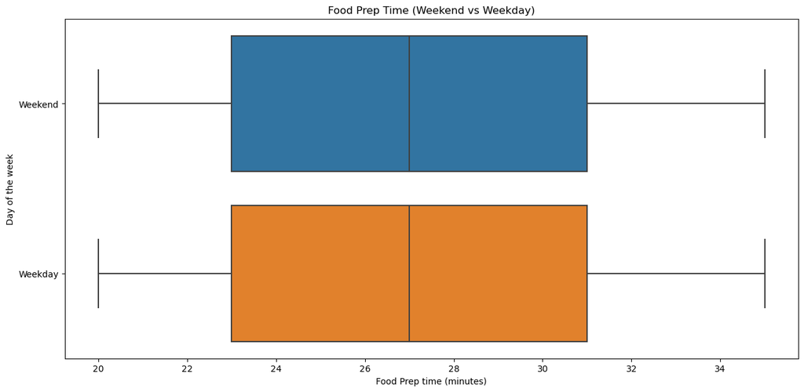

```python
#set the plot size
plt.figure(figsize=(15, 7))

# Create seaborn boxplot to show the food preparation time on weekdays and weekend
box_day = sns.boxplot(data=df,x='food_preparation_time', y='day_of_the_week')#specify axis labels

#set axis labels
box_day.set(ylabel='Day of the week',
       xlabel='Food Prep time (minutes)',
       title='Food Prep Time (Weekend vs Weekday)')


plt.show()
```

#### Observations

- FOod prep time is equally distributed on weekend and weekdays across all orders.

#### Restaurant count by cuisine

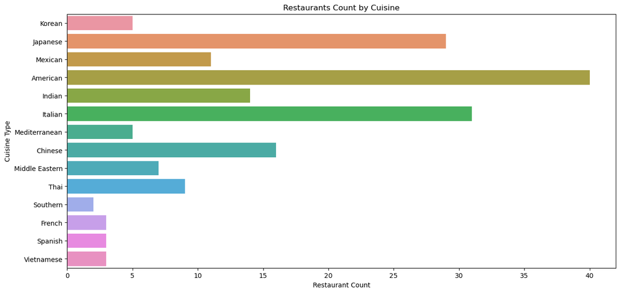

```python
# setup data frame that identifies unique restaurants by cuisine
unique_restaurants = df.drop_duplicates(subset='restaurant_name')
#set chart size
plt.figure(figsize=(15, 7))
#countplot for cuisine type by restaurant unique
unique_rc = sns.countplot(data=unique_restaurants,y='cuisine_type');
#sets axis labels
unique_rc.set(ylabel='Cuisine Type',
       xlabel='Restaurant Count',
       title='Restaurants Count by Cuisine');

plt.show()
```

#### Observations

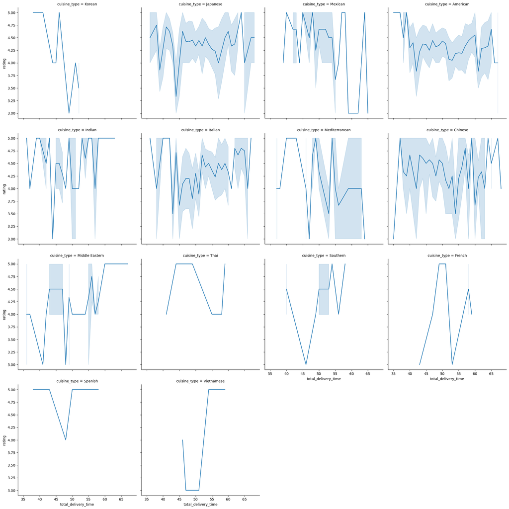

```python
#sets up a series of plots for cuisine and the relationship between rating and total delivery time
sns.relplot(data=df,x='total_delivery_time',y='rating', col='cuisine_type',kind='line', col_wrap=4);
```

### Correllation

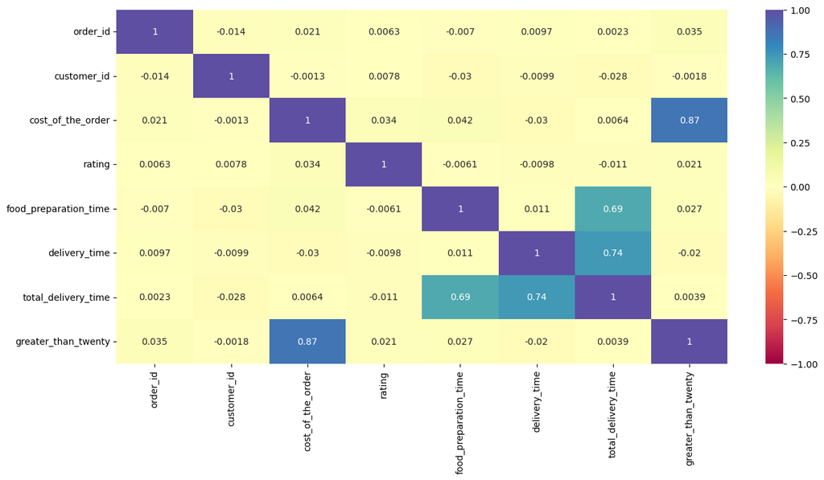

```python
#setup the variables we want to review for correlation
vars = ['order_id', 'customer_id','restaurant_name','cuisine_type','cost_of_the_order','day_of_the_week','rating','food_preparation_time','delivery_time']

#set the plotsize
plt.figure(figsize=(15, 7))

#run a correlation of the variables
corr = df[vars].corr(numeric_only=True);

sns.heatmap(df.corr(numeric_only=True),annot=True,cmap='Spectral',vmin=-1,vmax=1);
```

#### Observations

- There is no notable correlation between the original variables in the data set. In the correlation plot, there were som variables "Total Delivery Time" that were closely related to delivery time and prep time but only because total delivery time was derived.

#### Top 10 restaurants with highest total delivery time

```python
#shows the top 10 restaurants with highest total delivery time
rest_delivery_worst10 = df.groupby(["restaurant_name"]).mean(numeric_only=True).sort_values("total_delivery_time", ascending=False).head(10)
rest_delivery_worst10
```

| restaurant_name | order_id | customer_id | cost_of_the_order | rating | food_preparation_time | delivery_time | total_delivery_time | greater_than_twenty |
| --- | --- | --- | --- | --- | --- | --- | --- | --- |
| Taro Sushi | 1478227.0 | 367591.00 | 16.0500 | 5.0 | 35.0 | 32.00 | 67.00 | 0.0 |
| Cipriani Le Specialita | 1478151.0 | 62941.00 | 5.9200 | 5.0 | 35.0 | 30.00 | 65.00 | 0.0 |
| Il Bambino | 1478326.0 | 82901.00 | 29.2500 | 4.0 | 34.0 | 29.00 | 63.00 | 1.0 |
| Sushi Choshi | 1477800.0 | 344268.00 | 13.7300 | 3.0 | 35.0 | 27.00 | 62.00 | 0.0 |
| Big Wong Restaurant _¤¾Ñ¼ | 1477895.0 | 143926.00 | 5.9200 | NaN | 34.0 | 28.00 | 62.00 | 0.0 |
| Crema Restaurante | 1477494.0 | 300003.00 | 15.8600 | NaN | 31.0 | 30.00 | 61.00 | 0.0 |
| Grand Sichuan International | 1477564.5 | 194136.75 | 19.5225 | 5.0 | 31.0 | 29.25 | 60.25 | 0.5 |
| Mira Sushi | 1477448.0 | 85166.50 | 12.4200 | 4.0 | 32.5 | 27.50 | 60.00 | 0.0 |
| Hot Kitchen | 1477058.5 | 103147.00 | 21.2700 | 5.0 | 33.0 | 26.50 | 59.50 | 0.5 |
| Spice Thai | 1477832.0 | 100778.00 | 15.8600 | NaN | 34.0 | 25.00 | 59.00 | 0.0 |

#### Top 20 restaurants with lowest average rating across their orders

```python
#shows the worst 20 restaurant by rating
rest_rating_worst20 = df.groupby(["restaurant_name"]).mean(numeric_only=True).sort_values("rating", ascending=True).head(20)
rest_rating_worst20
```

| restaurant_name | order_id | customer_id | cost_of_the_order | rating | food_preparation_time | delivery_time | total_delivery_time | greater_than_twenty |
| --- | --- | --- | --- | --- | --- | --- | --- | --- |
| Sarabeth's West | 1.476843e+06 | 361846.000000 | 14.120000 | 3.000000 | 21.000000 | 33.000000 | 54.000000 | 0.000000 |
| Nha Trang One | 1.476837e+06 | 147468.000000 | 15.670000 | 3.000000 | 23.000000 | 24.000000 | 47.000000 | 0.000000 |
| Haveli Indian Restaurant | 1.477108e+06 | 370405.000000 | 17.410000 | 3.000000 | 23.500000 | 25.000000 | 48.500000 | 0.500000 |
| Woorijip | 1.476856e+06 | 59674.000000 | 8.250000 | 3.000000 | 26.000000 | 26.000000 | 52.000000 | 0.000000 |
| brgr | 1.476974e+06 | 76317.000000 | 9.895000 | 3.000000 | 25.000000 | 25.000000 | 50.000000 | 0.000000 |
| Byblos Restaurant | 1.477741e+06 | 260844.000000 | 24.735000 | 3.000000 | 32.500000 | 18.000000 | 50.500000 | 1.000000 |
| Sushi Choshi | 1.477800e+06 | 344268.000000 | 13.730000 | 3.000000 | 35.000000 | 27.000000 | 62.000000 | 0.000000 |
| Pepe Giallo | 1.476808e+06 | 84700.000000 | 14.600000 | 3.000000 | 32.000000 | 24.000000 | 56.000000 | 0.000000 |
| Cafeteria | 1.477560e+06 | 117196.111111 | 13.900000 | 3.250000 | 29.333333 | 24.000000 | 53.333333 | 0.111111 |
| Blue Ribbon Brooklyn | 1.477495e+06 | 323569.000000 | 16.530000 | 3.333333 | 27.250000 | 23.500000 | 50.750000 | 0.500000 |
| The Odeon | 1.477389e+06 | 132940.666667 | 11.170000 | 3.500000 | 31.666667 | 23.666667 | 55.333333 | 0.000000 |
| Don's Bogam BBQ & Wine Bar | 1.477314e+06 | 242102.333333 | 12.970000 | 3.500000 | 30.000000 | 20.666667 | 50.666667 | 0.000000 |
| Terakawa Ramen | 1.477090e+06 | 180423.333333 | 14.263333 | 3.500000 | 26.666667 | 22.333333 | 49.000000 | 0.000000 |
| Pylos | 1.477770e+06 | 83076.800000 | 18.850000 | 3.500000 | 25.800000 | 26.800000 | 52.600000 | 0.200000 |
| Go! Go! Curry! | 1.477604e+06 | 134208.666667 | 22.410000 | 3.500000 | 22.000000 | 23.666667 | 45.666667 | 0.666667 |
| Sarabeth's East | 1.477831e+06 | 109255.142857 | 16.091429 | 3.666667 | 28.857143 | 23.571429 | 52.428571 | 0.285714 |
| Waverly Diner | 1.477486e+06 | 343918.571429 | 15.210000 | 3.750000 | 25.000000 | 24.142857 | 49.142857 | 0.142857 |
| Hatsuhana | 1.477554e+06 | 86165.666667 | 18.796667 | 4.000000 | 28.000000 | 25.166667 | 53.166667 | 0.333333 |
| Mira Sushi | 1.477448e+06 | 85166.500000 | 12.420000 | 4.000000 | 32.500000 | 27.500000 | 60.000000 | 0.000000 |
| The MasalaWala | 1.477839e+06 | 75548.000000 | 12.130000 | 4.000000 | 32.000000 | 15.000000 | 47.000000 | 0.000000 |

### **Question 13:** The company wants to provide a promotional offer in the advertisement of the restaurants. The condition to get the offer is that the restaurants must have a rating count of more than 50 and the average rating should be greater than 4. Find the restaurants fulfilling the criteria to get the promotional offer. [3 marks]

```python
#Does a group by of the restaurants rating then aggregates the sum, mean and counts so we can do additional analysis
restaurant= df.groupby('restaurant_name')[['rating']].agg(['sum','mean','count'])

#Filter down to provide restaurants with an average rating > 4 and a total rating count of > 50
restaurant= restaurant[(restaurant['rating']['mean']>4) & (restaurant['rating']['count']>50)]
restaurant
```

| restaurant_name | rating sum | rating mean | rating count |
| --- | --- | --- | --- |
| Blue Ribbon Fried Chicken | 277.0 | 4.328125 | 64 |
| Blue Ribbon Sushi | 308.0 | 4.219178 | 73 |
| Shake Shack | 569.0 | 4.278195 | 133 |
| The Meatball Shop | 379.0 | 4.511905 | 84 |

#### Observations:

4 Restaurants met the criteria of a rating count of more than 50 and the average rating greater than 4.

1. The Meatball Shop
2. Blue Ribbon Fried Chicken
3. Shake Shack
4. Blue Ribbon Sushi

### **Question 14:** The company charges the restaurant 25% on the orders having cost greater than 20 dollars and 15% on the orders having cost greater than 5 dollars. Find the net revenue generated by the company across all orders. [3 marks]

```python
# Setup big order revenue dataframe where cost of order > 20 dollars
net_revenue_big_orders = df[df['cost_of_the_order']>20 ]

# Setup big order revenue dataframe where cost of order > 5 dollars but less than 21 dollars
net_revenue_small_orders = df[(df['cost_of_the_order']>5) & (df['cost_of_the_order']<21)]

# Calculate net revenue small orders with 15% of the order costs
net_revenue_small_orders = net_revenue_small_orders['cost_of_the_order'] *.15

# Calculate net revenue big orders with 25% of the order costs
net_revenue_big_orders = net_revenue_big_orders['cost_of_the_order'] *.25

print('The net revenue is $', round(net_revenue_big_orders.sum() + net_revenue_small_orders.sum(),2),sep='')
```

```
The net revenue is $6236.45
```

#### Observations:

- no notable observations as we are just doing a calculation of the revenue.
- The net revenue is $6236.45

### **Question 15:** The company wants to analyze the total time required to deliver the food. What percentage of orders take more than 60 minutes to get delivered from the time the order is placed? (The food has to be prepared and then delivered.) [2 marks]

```python
# Calculate the percentage of the time total delivery was more than 60 minutes
round(len(df[df['total_delivery_time']>60]) / len(df)*100,2)

print('The total delivery time is greater than 60 minutes ', round(len(df[df['total_delivery_time']>60]) / len(df)*100,2), '% of the time.', sep='')
```

```
The total delivery time is greater than 60 minutes 10.54% of the time.
```

#### Observations:

The total delivery time is greater than 60 minutes 10.54% of the time.

### **Question 16:** The company wants to analyze the delivery time of the orders on weekdays and weekends. How does the mean delivery time vary during weekdays and weekends? [2 marks]

```python
# Produce a dataframe that does a group by day of week and sets up a column for deliveyr time
day_of_week_delivery = df.groupby('day_of_the_week')[['delivery_time']]

#Calculate and display the mean delivery time on weekday vs weekend, round to 2
day_of_week_delivery.mean().round(2)
```

| day_of_the_week | delivery_time |
| --- | --- |
| Weekday | 28.34 |
| Weekend | 22.47 |

### Recommendations:

**Suggestion 1**:  
I recommend investigating why delivery takes longer on weekdays, do we lack enough drivers? Might it have to do with traffic issues that cause the increased time? Perhaps Foodhub has less delivery employees available at Foodhub on the weekday contributing to the problem.  
**Suggestion 2**:  
We don't have data on customers beyond just this rating, I suggest we collect additional open end information from customers that we can analyze to provide additional insights.  
**Suggestion 3**:  
I recommend should ask to get additional data on the delivery employee id's to get an understanding of that population and look at the relationship with the order data.  
**Suggestion 4**:  
I recommend building a report that identifies the trends for each restaurant to show them their food_prep_time metrics, this could be an opportunity to allow them to improve their performance therefore inproving overall delivery time and customer satisfaction.  
**Suggestion 5**:  
In the data analysis, we can see that Vietnamese, French, Southern and French have the lowest amount of restaurants represented and also the least amount of orders. We could try to boost identifying additional opportunities in these cuisine types to boost sales.  
**Suggestion 6**:  
Foodhub is not giving out that many promotional offers (only to 4 restaurants) so in order to provide more appropriate incentive to improve business, lowering the threshold from 50 to a smaller amount of ratings might help to increase participation and improve interest in Foodhub to other customers.